# Report: act_report

## Analyzing and Visualizing Data

Using 3 dataset, I tried to find answers to the 3 questions below.

1. Are retweet counts and favorite counts related to the rating?
2. Does tweets uploaded on weekends have more retweet counts / favorite counts?
3. Which breeds of dogs are the top 10 most frequently uploaded for WeRateDog tweets?

### 1. Are retweet counts and favorite counts related to the rating?

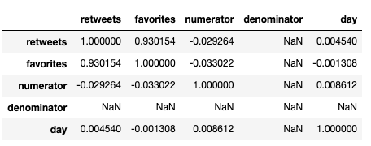

```python
from IPython.display import Image
Image(filename='image_correlation.png')
```

I wondered if there is any correlation between retweets/favorites counts and rating. And when I see the correlation of each variable in `df_archive`, it turned out that *retweets* and *favorites* have very strong positive correlation, but for the **ratings (*numerator* here)**, it has **very weak correlation** with *retweets* and *favorites* counts.

### 2. Does tweets uploaded on weekends have more retweet counts / favorite counts?

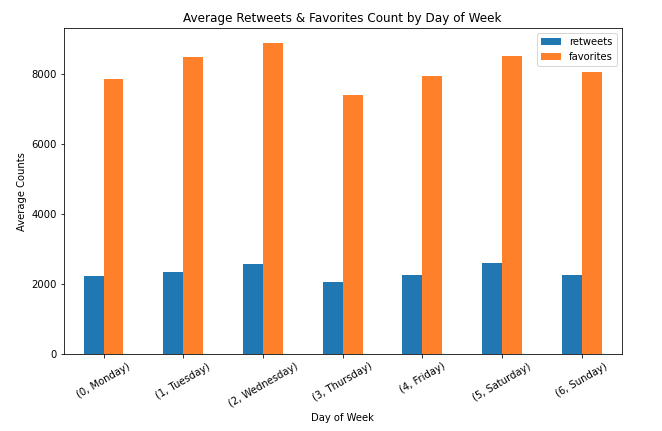

```python
from IPython.display import Image
Image(filename='image_dayofweek.png')
```

I guessed there would be difference in the average counts of tweet posts according to the day of week, but in the result, **the average retweets & favorite counts was almost similar regardless of what day of the week**. Only **Thursday** has a bit lower average counts of both *retweets* and *favorites* compared to the other day of week.

### 3. Which breeds of dogs are the top 10 most frequently uploaded for WeRateDog tweets?

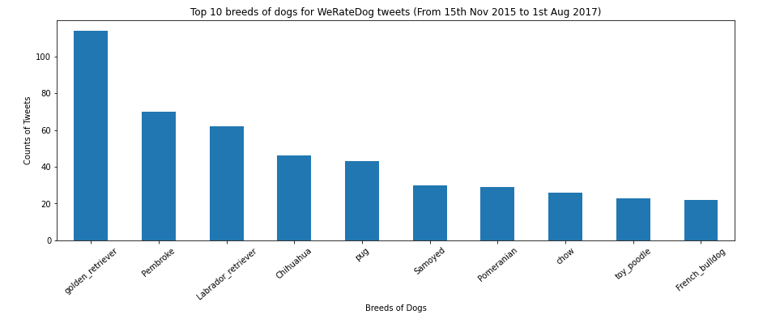

```python
from IPython.display import Image
Image(filename='image_top10breeds.png')
```

As shown in the above chart, **the most frequent breeds of dogs** for WeRateDog tweets was **"Golden Retriever"** and "Pembroke", "Labrador Retriever" was ranked second and third each and so on. *(Based on the WeRateDog tweets data from 2015.11.15 to 2017.08.01)*